# Does design region choice change what RFdiffusion can build?

Three contig strategies on the same input complex (crystal, 64 designs each)

Published

August 29, 2026

## 1 The question

Three campaign runs share an input complex, a design count and every downstream setting. They differ only in the contig string, so any difference in what RFdiffusion builds is attributable to how the design regions were chosen.

| run | regions | designed residues | how the regions were chosen |
| --- | --- | --- | --- |
| `crystal_full_test_contig` | 2 | 16–26 | hand-picked, two contiguous blocks |
| `crystal_auto5A_contig` | 4 | 21–45 | auto-derived from effector contact at 5 Å |
| `crystal_auto3A_contig` | 6 | 10–19 | auto-derived from effector contact at 3 Å |

The `posed_*` runs are excluded, since they change the input structure as well as the contig. `crystal_full_r1_17to21_contig` is excluded because it varies only the allowed length of one region, which is the within-strategy question rather than the between-strategy one.

Everything below reads `data/<run>.json`, the per-run `rfdiffusion_metrics.json` the pipeline already writes, so nothing is recomputed from structures.

```python
import sys
from pathlib import Path

import numpy as np
import pandas as pd

HERE = Path.cwd()
if not (HERE / "novelty_common.py").exists():
    HERE = Path("experiments/campaigns/pikp1_avrpikf/analyses/design_region_novelty")
sys.path.insert(0, str(HERE.resolve()))

import novelty_common as nc  # noqa: E402

nc.apply_style()
regions = nc.load_regions()
designs = nc.load_designs()
```

## 2 Where the design regions sit

Length and placement are different arguments and the summary tables only carry length, so the contig strings are drawn directly.

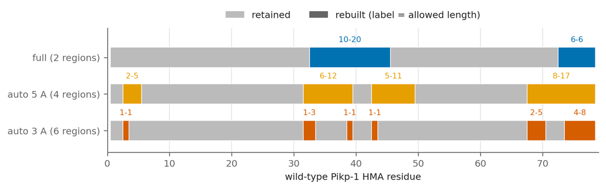

Figure 1: The three contig strategies along wild-type Pikp-1 HMA numbering. Grey is retained scaffold, colour is rebuilt. Labels give the allowed length range for each design region.

```python
_ = nc.fig_contig_map()
```

- The two strategies are not simply coarse and fine versions of each other. `full` rebuilds one large block in the middle of the domain and the C terminus, while both auto strategies scatter regions across the whole length.
- `auto 3 Å` has the most regions but the fewest designed residues, because four of its six regions are one or two residues wide.

## 3 Displacement tracks length, but not equally between strategies

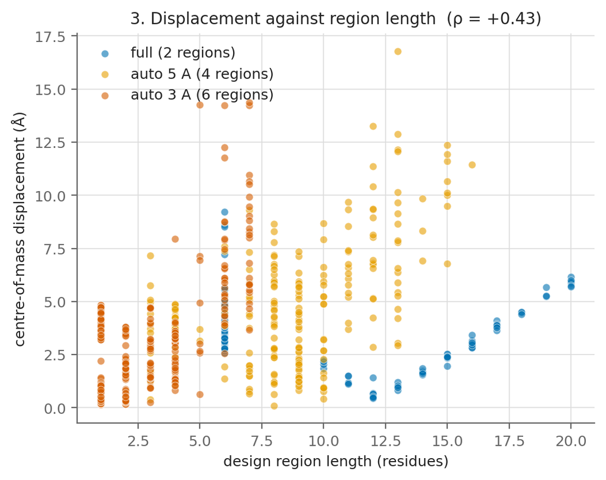

Figure 2: Centre-of-mass displacement of each rebuilt region against its length, pooled over designs and regions. One point per (design, region).

```python
from IPython.display import Image
Image(str(nc.PLOTS / "03_com_vs_length.png"))
```

- Displacement rises with region length across the pooled data, so any comparison between strategies has to account for the fact that they allow different lengths.
- The strategies do not merely occupy different parts of that trend. `full` forms a tight, almost linear band, whereas both auto strategies spread widely at every length, including at one and two residues where there is very little to rebuild.

## 4 How much of that displacement is the scaffold moving?

Displacement is measured after aligning on the retained scaffold, so it only means “the region was rebuilt somewhere new” if the scaffold itself held still.

```python
(designs.groupby("run", sort=False)
        .agg(designs=("design", "size"),
             median_total_designed=("total_designed", "median"),
             median_motif_rmsd=("motif_rmsd", "median"),
             median_coverage=("design_region_coverage", "median"))
        .round(3))
```

Table 1: Retained-scaffold RMSD to the input, per strategy.

| run | designs | median_total_designed | median_motif_rmsd | median_coverage |
| --- | --- | --- | --- | --- |
| full (2 regions) | 64 | 21.0 | 0.074 | 0.640 |
| auto 5 A (4 regions) | 64 | 33.0 | 4.006 | 0.534 |
| auto 3 A (6 regions) | 64 | 15.0 | 2.632 | 0.667 |

- The retained scaffold barely moves under `full`, at a median motif RMSD of 0.07 Å, but moves 2.6 Å and 4.0 Å under `auto 3 Å` and `auto 5 Å`.
- Part of the auto strategies’ apparent displacement is therefore the domain drifting rather than the region being rebuilt somewhere novel, so the scatter in the previous figure overstates how much extra novelty they buy.

## 5 Placement within a strategy

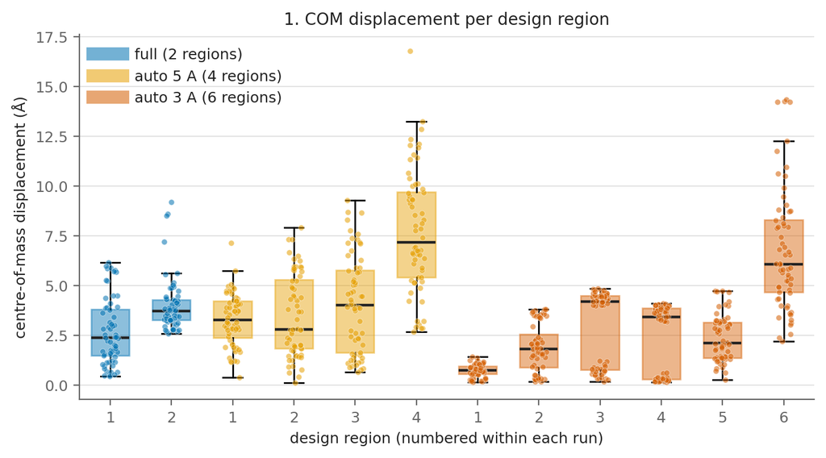

Figure 3: Centre-of-mass displacement per design region, grouped by strategy. Regions are numbered N to C along the receptor.

```python
Image(str(nc.PLOTS / "01_com_displacement_by_region.png"))
```

```python
(regions.groupby(["run", "region"], sort=False)
        .agg(n=("design", "size"), median_length=("length", "median"),
             median_com=("com_displacement", "median"),
             median_com_per_res=("com_per_residue", "median"))
        .round(3).reset_index())
```

Table 2: Per-region length and displacement, by strategy.

|  | run | region | n | median_length | median_com | median_com_per_res |
| --- | --- | --- | --- | --- | --- | --- |
| 0 | full (2 regions) | 1 | 64 | 15.0 | 2.386 | 0.166 |
| 1 | full (2 regions) | 2 | 64 | 6.0 | 3.730 | 0.622 |
| 2 | auto 5 A (4 regions) | 1 | 64 | 4.0 | 3.286 | 0.940 |
| 3 | auto 5 A (4 regions) | 2 | 64 | 9.0 | 2.812 | 0.349 |
| 4 | auto 5 A (4 regions) | 3 | 64 | 8.0 | 4.016 | 0.511 |
| 5 | auto 5 A (4 regions) | 4 | 64 | 12.0 | 7.172 | 0.602 |
| 6 | auto 3 A (6 regions) | 1 | 64 | 1.0 | 0.749 | 0.749 |
| 7 | auto 3 A (6 regions) | 2 | 64 | 2.0 | 1.828 | 0.784 |
| 8 | auto 3 A (6 regions) | 3 | 64 | 1.0 | 4.187 | 4.187 |
| 9 | auto 3 A (6 regions) | 4 | 64 | 1.0 | 3.432 | 3.432 |
| 10 | auto 3 A (6 regions) | 5 | 64 | 4.0 | 2.104 | 0.546 |
| 11 | auto 3 A (6 regions) | 6 | 64 | 6.0 | 6.062 | 0.995 |

- Displacement varies more between regions within a strategy than it does between strategies, and the C-terminal region moves furthest in all three, at 3.7, 7.2 and 6.1 Å.
- That region is terminal and anchored on one side only, so placement rather than length is what frees it, which is the same conclusion the per-residue column reaches for the single-residue regions of `auto 3 Å`.

## 6 Does region length change how varied the designs are?

Region 1 has a 10-20 residue allowance, so RFdiffusion picked a different length in different designs. Comparing across those lengths is free of any between-run or between-region confound, unlike the three-strategy comparison in the three-strategy comparison above.

Diversity is the mean nearest-neighbour distance between two designs’ Ca coordinates for the same region, which is defined when the two have different residue counts. Each design is compared only with designs that came out the same length. Comparing against the whole pool instead gives a spurious U, because RFdiffusion sampled lengths unevenly around 15 and the extremes then score as distant for being a minority rather than for varying among themselves.

Numbers here use the `.trb`-corrected residue mapping. The pipeline’s own `per_region_lengths` are a proportional guess, wrong for most designs of any contig with several variable-length regions. See `trb_metrics.py`.

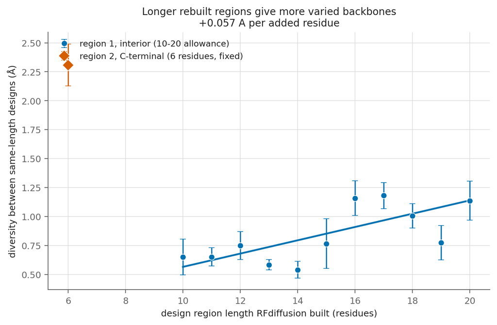

```python
from IPython.display import Image
Image("plots/11_length_vs_diversity.png")
```

```python
print(open("length_diversity_stats.txt").read())
```

```
full region 1, n=64 designs, lengths 10-20
diversity = mean chamfer distance to same-length designs only
  linear     slope +0.0574 A/res  p=1.05e-06  R2=0.321
  quadratic  quad  +0.00053  p=0.882  (F-test vs linear p=0.882, not supported)
  group-level Spearman over the 11 lengths: rho=+0.71, p=0.0146
  diversity at 10 res 0.65 A, at 20 res 1.14 A
full region 2 (C-terminal, 6 res, n=64): 2.31 +- 0.18 A

NOTE: distance-to-all-designs instead of within-length produces a spurious
U shape, because RFdiffusion sampled lengths unevenly around 15 and the
extremes score as distant for being a minority rather than for varying.
```

## 7 What this supports

Caveats.

- One input complex and one effector, 64 designs per strategy. The contig strings differ in placement and in length at once, so no single comparison isolates either on its own.
- Centre-of-mass displacement says where a region ended up, not what it looks like. Two very different backbones with the same centroid are indistinguishable here.
- The auto strategies’ motif RMSD means their displacement is measured in a frame that itself moved, so their values are not on the same footing as `full`’s.